# 9_1_K_Regression

Author

Alexa Marin

# K-Nearest Neighbors and Decision Trees for Regression

Before we implement models using scikit-learn, let’s think conceptually about the $k$-nearest neighbors and decision tree algorithms for regression.

```python
import pandas as pd

import numpy as np

import matplotlib.pyplot as plt
```

## Visualizing K-Nearest Neighbors Regression Functions

A predictive model is simply a function $f$ that maps feature values ${\bf x}$ to target values $y$. We can visualize $f$ when ${\bf x}$ consists of just a single feature. We have seen that a linear regression function $f$ based on a single feature $x$ is a linear function of $x$. What does $f$ look like when the model is a $k$-nearest neighbors regressor?

### K-Nearest Neighbors Regression Functions for a Single Quantitative Feature: Wine Data

Recall the wines data set where our target is log(price), a proxy for quality. We’ll use a K-Nearest Neighbors model for predicting log(price) from a single feature, age.

First, we extract the training data. There is no need to scale the features in this case because there is only one feature. (The point of scaling is to bring all of the *feature* variables to the same scale before computing distances between observations.)

```python
bordeaux_df = pd.read_csv("https://dlsun.github.io/pods/data/bordeaux.csv",
                          index_col="year")

# Split the data into training and test sets
bordeaux_train = bordeaux_df.loc[:1980].copy()
bordeaux_test = bordeaux_df.loc[1981:].copy()

# Log transform the target
bordeaux_train["log(price)"] = np.log(bordeaux_train["price"])

# train on a single feature, age
X_train = bordeaux_train[["age"]]
y_train = bordeaux_train["log(price)"]
```

```python
bordeaux_train[["age", "log(price)"]].sort_values("age").head(5)
```

| year | age | log(price) |
| --- | --- | --- |
| 1980 | 12 | 2.639057 |
| 1979 | 13 | 3.044522 |
| 1978 | 14 | 3.295837 |
| 1977 | 15 | 2.397895 |
| 1976 | 16 | 3.218876 |

Let’s make a scatterplot of the training data. Careful! In the reading, we made several scatterplots where both the x-axis and y-axis corresponded to *feature* variables (and the target corresponded to color). But now the x-axis is the feature and the y-axis is the target.

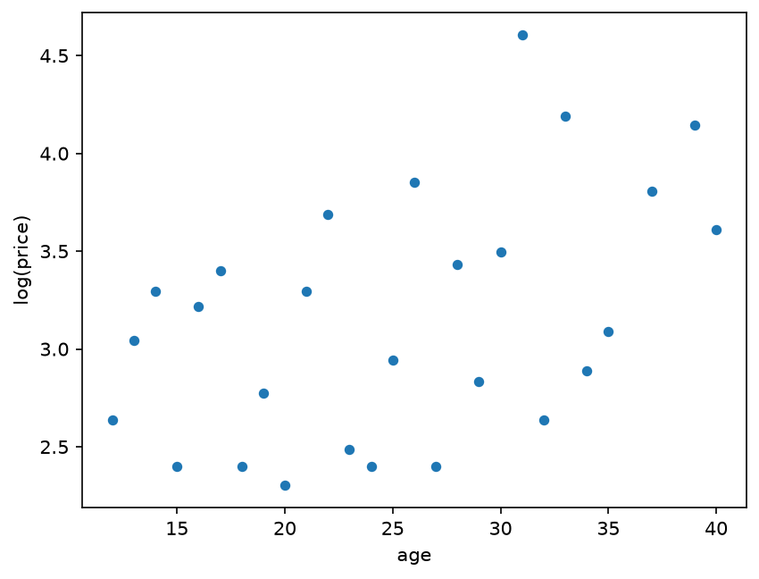

```python
bordeaux_train.plot.scatter(x="age", y="log(price)")
```

1. Consider a **1-nearest neighbor** regression model. Say we want to add the regression function to the scatterplot. Sketch a plot of what the regression function would look like. **Discuss with your partner before proceeding.** Hint: The smallest ages in the training data are 12, 13, 14, etc. What would the predicted price be for age = 12? age = 13? age = 11.5? age = 12.49? age = 12.51? age = 13.49? age = 13.51?

**Sketch on paper and discuss with your partner.** The line would look like steps. At every age, it predicts the log(price) from the closest wine age in the training data. So 12, 12.49, and 11.5 use the age-12 wine; 12.51 and 13.49 use age 13; and 13.51 uses age 14. The line changes halfway between each age.

2. Consider a **2-nearest neighbor** regression model. Say we want to add the regression function to the scatterplot. Sketch a plot of what the regression function would look like. **Discuss with your partner before proceeding.** Hint: The smallest ages in the training data are 12, 13, 14, etc. What would the predicted price be for age = 12? age = 12.99? age = 13.01? age = 13.99? age = 14.01?

**Sketch on paper and discuss with your partner.** This is still a step-looking line, but every prediction is the average log(price) of the two closest wines. At 12.99, it averages ages 12 and 13. At 13.01, it averages ages 13 and 14. It is smoother than k = 1 because it is not relying on only one wine.

3. What would the 27-nearest neighbors regression function look like? **Discuss with your partner before proceeding.** Hint: what is special about 27 in this example?

**Sketch on paper and discuss with your partner.** There are 27 wines in the training data, so k = 27 uses every single wine for each prediction. The regression line would be one flat horizontal line at the average log(price) of all 27 wines.

4. Now we’ll fit a K-nearest neighbors regression model and plot the regression function for K=1, 2, 10, 27. The code below basically implements the code from the previous part for each of the values of K. Run the code and **discuss the output with your partner**. Do the regression functions look like what you expected? What happens as K increases?

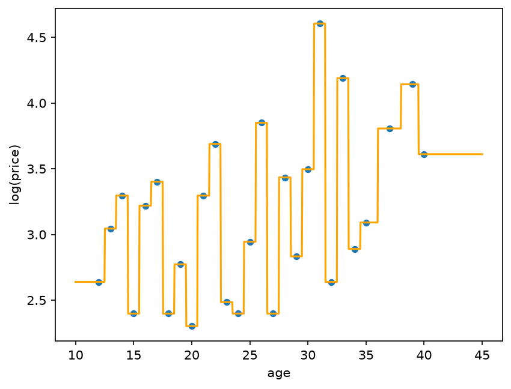

```python
# 1-nearest neighbor model
from sklearn.neighbors import KNeighborsRegressor

# Fit k-nearest neighbors
model = KNeighborsRegressor(n_neighbors=1)
model.fit(X=X_train, y=y_train)

# Define a grid of feature values to make predictions for
X_new = pd.DataFrame()
X_new["age"] = np.linspace(10, 45, num=1000)

# Make predictions at those feature values.
y_new_ = pd.Series(
    # ADD YOUR CODE HERE,
    model.predict(X_new),
    index=X_new["age"]
)

# Plot the scatter plot and the predictions (regression function)
bordeaux_train.plot.scatter(x="age", y="log(price)")
y_new_.plot.line(color = "orange")
```

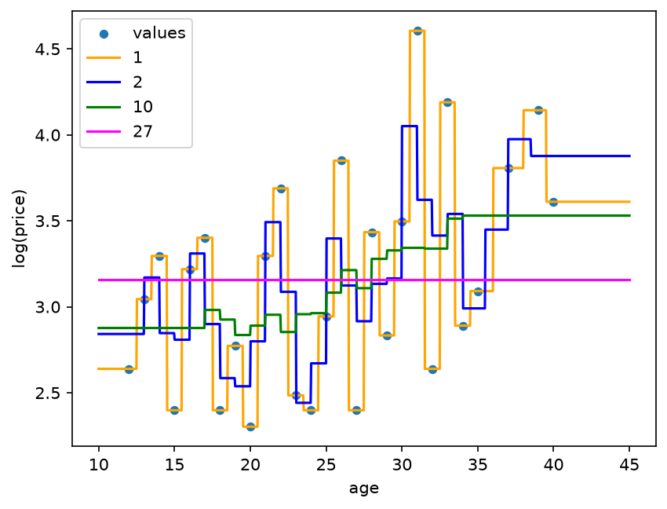

```python
# k-nearest neighbors for several values of k
ks = [1, 2, 10, 27]
colors = ["orange", "blue", "green", "magenta", "black"]

bordeaux_train.plot.scatter(x="age", y="log(price)")

# Define a grid of feature values.
X_new = pd.DataFrame()
X_new["age"] = np.linspace(10, 45, num=1000)

for i in range(len(ks)):

  # Fit k-nearest neighbors
  model = KNeighborsRegressor(n_neighbors=ks[i])
  model.fit(X=X_train, y=y_train)

  # Make predictions at those feature values.
  y_new_ = pd.Series(
      model.predict(X_new),
      index=X_new["age"]
  )

  # Plot the predictions.
  y_new_.plot.line(color = colors[i])
  plt.legend(["values"] + ks);
```

### K-Nearest Neighbors Regression Functions for a Single Categorical Feature: Housing Data

Recall the Ames housing data set. We’ll use a single categorical feature—Neighborhood—to predict SalePrice.

```python
df_ames = pd.read_csv("http://dlsun.github.io/pods/data/AmesHousing.txt", sep = "\t")

df_ames[["Neighborhood", "SalePrice"]]
```

|  | Neighborhood | SalePrice |
| --- | --- | --- |
| 0 | NAmes | 215000 |
| 1 | NAmes | 105000 |
| 2 | NAmes | 172000 |
| 3 | NAmes | 244000 |
| 4 | Gilbert | 189900 |
| ... | ... | ... |
| 2925 | Mitchel | 142500 |
| 2926 | Mitchel | 131000 |
| 2927 | Mitchel | 132000 |
| 2928 | Mitchel | 170000 |
| 2929 | Mitchel | 188000 |

2930 rows × 2 columns

We’ll fit a **10-nearest neighbors** regression model to predict house price using **Neighborhood** as the only feature. Since Neighborhood is categorical we first need to convert it to dummies, using a `ColumnTransformer` and a `Pipeline`.

```python
from sklearn.compose import ColumnTransformer
from sklearn.neighbors import KNeighborsRegressor
from sklearn.pipeline import Pipeline
from sklearn.preprocessing import OneHotEncoder

X = df_ames[["Neighborhood"]]
y = df_ames["SalePrice"]

ct = ColumnTransformer(
    [("dummify", OneHotEncoder(), ["Neighborhood"])]
)

knn_model = Pipeline([
    ("preprocessing", ct),
    ("knn", KNeighborsRegressor(n_neighbors=10))
])

knn_model.fit(X, y)
```

```
Pipeline(steps=[('preprocessing',
                 ColumnTransformer(transformers=[('dummify', OneHotEncoder(),
                                                  ['Neighborhood'])])),
                ('knn', KNeighborsRegressor(n_neighbors=10))])
```

Now we’ll find the predicted price for each Neighborhood.

```python
neighborhoods = pd.Series(df_ames["Neighborhood"].unique(), name="Neighborhood").to_frame()
neighborhoods["predicted"] = knn_model.predict(neighborhoods)
neighborhoods
```

|  | Neighborhood | predicted |
| --- | --- | --- |
| 0 | NAmes | 142771.0 |
| 1 | Gilbert | 221722.5 |
| 2 | StoneBr | 300637.0 |
| 3 | NWAmes | 180795.0 |
| 4 | Somerst | 230960.0 |
| 5 | BrDale | 108850.0 |
| 6 | NPkVill | 140115.0 |
| 7 | NridgHt | 346588.3 |
| 8 | Blmngtn | 209917.9 |
| 9 | NoRidge | 325105.0 |
| 10 | SawyerW | 169140.0 |
| 11 | Sawyer | 141880.0 |
| 12 | Greens | 181175.0 |
| 13 | BrkSide | 118810.0 |
| 14 | OldTown | 121880.0 |
| 15 | IDOTRR | 121150.4 |
| 16 | ClearCr | 222100.0 |
| 17 | SWISU | 134050.0 |
| 18 | Edwards | 130960.0 |
| 19 | CollgCr | 165843.2 |
| 20 | Crawfor | 245010.0 |
| 21 | Blueste | 143590.0 |
| 22 | Mitchel | 141000.0 |
| 23 | Timber | 228758.9 |
| 24 | MeadowV | 104390.0 |
| 25 | Veenker | 254750.0 |
| 26 | GrnHill | 150790.0 |
| 27 | Landmrk | 122920.0 |

Let’s compare the predicted prices to the mean price for each neighborhood.

```python
pd.merge(pd.merge(neighborhoods,
                  df_ames.groupby("Neighborhood")["SalePrice"].mean(), left_on = "Neighborhood", right_index = True),
         df_ames["Neighborhood"].value_counts(), left_on = "Neighborhood", right_index = True).sort_values("count")
```

|  | Neighborhood | predicted | SalePrice | count |
| --- | --- | --- | --- | --- |
| 27 | Landmrk | 122920.0 | 137000.000000 | 1 |
| 26 | GrnHill | 150790.0 | 280000.000000 | 2 |
| 12 | Greens | 181175.0 | 193531.250000 | 8 |
| 21 | Blueste | 143590.0 | 143590.000000 | 10 |
| 6 | NPkVill | 140115.0 | 140710.869565 | 23 |
| 25 | Veenker | 254750.0 | 248314.583333 | 24 |
| 8 | Blmngtn | 209917.9 | 196661.678571 | 28 |
| 5 | BrDale | 108850.0 | 105608.333333 | 30 |
| 24 | MeadowV | 104390.0 | 95756.486486 | 37 |
| 16 | ClearCr | 222100.0 | 208662.090909 | 44 |
| 17 | SWISU | 134050.0 | 135071.937500 | 48 |
| 2 | StoneBr | 300637.0 | 324229.196078 | 51 |
| 9 | NoRidge | 325105.0 | 330319.126761 | 71 |
| 23 | Timber | 228758.9 | 246599.541667 | 72 |
| 15 | IDOTRR | 121150.4 | 103752.903226 | 93 |
| 20 | Crawfor | 245010.0 | 207550.834951 | 103 |
| 13 | BrkSide | 118810.0 | 124756.250000 | 108 |
| 22 | Mitchel | 141000.0 | 162226.631579 | 114 |
| 10 | SawyerW | 169140.0 | 184070.184000 | 125 |
| 3 | NWAmes | 180795.0 | 188406.908397 | 131 |
| 11 | Sawyer | 141880.0 | 136751.152318 | 151 |
| 1 | Gilbert | 221722.5 | 190646.575758 | 165 |
| 7 | NridgHt | 346588.3 | 322018.265060 | 166 |
| 4 | Somerst | 230960.0 | 229707.324176 | 182 |
| 18 | Edwards | 130960.0 | 130843.381443 | 194 |
| 14 | OldTown | 121880.0 | 123991.891213 | 239 |
| 19 | CollgCr | 165843.2 | 201803.434457 | 267 |
| 0 | NAmes | 142771.0 | 145097.349887 | 443 |

5. For what neighborhood is the predicted price equal to the neighborhood’s mean price? Why? What is special about that neighborhood? Can you explain why the predicted prices don’t match the mean price for the other neighborhoods?

**Discuss with your partner.** Blueste is the neighborhood where the predicted price equals the neighborhood mean because it has exactly 10 homes. Since k = 10, the model uses all 10 Blueste homes. Neighborhoods with more than 10 homes only use the 10 closest homes, while neighborhoods with fewer than 10 homes have to include homes from other neighborhoods too.

### K-Nearest Neighbors Regression Functions for Two Quantitative Features: Sketching for Small Training Data

When there are multiple features, a regression function will be a surface in a higher dimensional space and is therefore difficult to visualize. Essentially the regression function splits the feature space into regions based on which $K$ points in the training data are closest, and makes constant predictions over these regions so that the regression surface has something like a [“log step”](https://i.pinimg.com/originals/f3/61/21/f36121c84fa42b6cad525f865d61d049.png) shape.

We’ll sketch plots of the regression surface when there are two quantitative features and the training data only contains a few observations. Assume that the features have already been scaled and that Euclidean distance is used to determine nearest neighbors.

6. Consider **1-nearest neighbors** regression model based on two quantitative features which have already been scaled. Imagine the training data set only contains 2 observations. Skecth a plot of the regression function. **Discuss with your partner.**

**Sketch on paper and discuss with your partner.** I would draw one straight boundary halfway between the two points. Everything on one side predicts the target value of the first point, and everything on the other side predicts the target value of the second point.

7. Consider **1-nearest neighbors** regression model based on two quantitative features which have already been scaled. Imagine the training data set only contains 3 observations. Skecth a plot of the regression function. **Discuss with your partner.**

**Sketch on paper and discuss with your partner.** I would draw three regions. Each region contains the places closest to one of the three points, and the prediction in that region is that point’s target value.

8. Consider **2-nearest neighbors** regression model based on two quantitative features which have already been scaled. Imagine the training data set only contains 3 observations. Skecth a plot of the regression function. **Discuss with your partner.**

**Sketch on paper and discuss with your partner.** I would still have three regions, but each region would use the average target value of the two closest points. The point that is farthest away is the one left out.

## Decision Trees

Back to the wine data. Suppose again that we want to predict log(price) based on just a single feature, age.

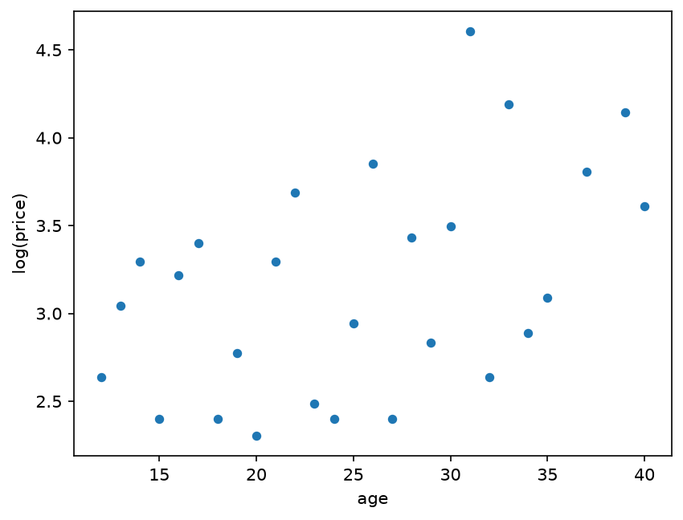

```python
bordeaux_train.plot.scatter(x="age", y="log(price)")
```

9. Suppose we use a regression decision tree with a single split at 20.5. Sketch a plot of what the regression function would look like.

**Sketch on paper and discuss with your partner.** The graph would have two flat steps. Every wine age at or below 20.5 gets the average log(price) on that side, and every age above 20.5 gets the average log(price) on the other side.

10. Suppose we use a decision tree with two splits at 20.5 and 30.5. Sketch a plot of what the regression function would look like.

**Sketch on paper and discuss with your partner.** The graph would have three flat steps: one for ages at or below 20.5, one for ages between 20.5 and 30.5, and one for ages above 30.5. Each step is the average log(price) for the wines in that group.

## Fitting KNN Regression Models with scikit-learn: Housing data

11. Fit a 10-nearest neighbors regression model that predicts the price (just **SalePrice**, not log) of a home using square footage (**Gr Liv Area**), number of bedrooms (**Bedroom AbvGr**), number of full bathrooms (**Full Bath**), number of half bathrooms (**Half Bath**), and **Neighborhood**. Use a pipeline and column transformers as needed. Make a scatter plot of predicting price versus actual price.

```
Test RMSE: 42561.87288594954
Test R-squared: 0.7740564772208821
```

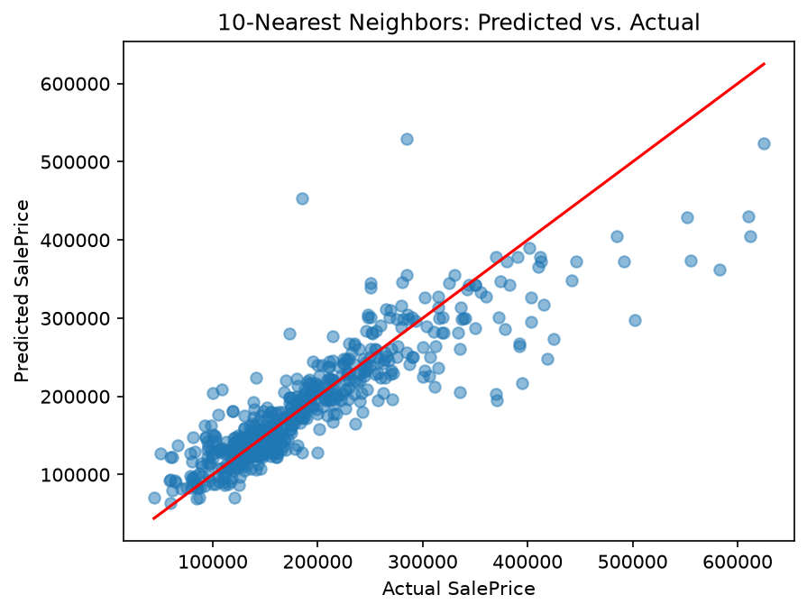

```python
# YOUR CODE HERE. ADD CELLS AS NEEDED
from sklearn.compose import ColumnTransformer
from sklearn.metrics import mean_squared_error, r2_score
from sklearn.model_selection import train_test_split
from sklearn.neighbors import KNeighborsRegressor
from sklearn.pipeline import Pipeline
from sklearn.preprocessing import OneHotEncoder, StandardScaler

features = ["Gr Liv Area", "Bedroom AbvGr", "Full Bath", "Half Bath", "Neighborhood"]
target = "SalePrice"

X = df_ames[features]
y = df_ames[target]

X_train, X_test, y_train, y_test = train_test_split(
    X,
    y,
    test_size=0.2,
    random_state=42
)

numeric_features = ["Gr Liv Area", "Bedroom AbvGr", "Full Bath", "Half Bath"]
categorical_features = ["Neighborhood"]

preprocessor = ColumnTransformer([
    ("scale", StandardScaler(), numeric_features),
    ("dummies", OneHotEncoder(handle_unknown="ignore"), categorical_features)
])

knn_10 = Pipeline([
    ("preprocessing", preprocessor),
    ("knn", KNeighborsRegressor(n_neighbors=10))
])

knn_10.fit(X_train, y_train)

pred_10 = knn_10.predict(X_test)

print("Test RMSE:", mean_squared_error(y_test, pred_10) ** 0.5)
print("Test R-squared:", r2_score(y_test, pred_10))

plt.scatter(y_test, pred_10, alpha=0.5)
plt.xlabel("Actual SalePrice")
plt.ylabel("Predicted SalePrice")
plt.title("10-Nearest Neighbors: Predicted vs. Actual")
plt.plot([y_test.min(), y_test.max()],
         [y_test.min(), y_test.max()],
         color="red")
plt.show()
```

12. Repeat the previous part to fit a $k$-nearest neighbors model for some other value of $k$. Experiment with different values of $k$. (For this, you can just pick and choose a few, no need to automate it. We’ll see how to do that later.) What value of $k$ seems to be “best”? How are you deciding?

```python
# YOUR CODE HERE. ADD CELLS AS NEEDED
k_values = [1, 3, 5, 10, 20, 40]

results = []

for k in k_values:
    model = Pipeline([
        ("preprocessing", preprocessor),
        ("knn", KNeighborsRegressor(n_neighbors=k))
    ])

    model.fit(X_train, y_train)

    predictions = model.predict(X_test)

    results.append({
        "k": k,
        "RMSE": mean_squared_error(y_test, predictions) ** 0.5,
        "R-squared": r2_score(y_test, predictions)
    })

results_df = pd.DataFrame(results).sort_values("RMSE")

results_df
```

|  | k | RMSE | R-squared |
| --- | --- | --- | --- |
| 2 | 5 | 42452.081051 | 0.775221 |
| 3 | 10 | 42561.872886 | 0.774056 |
| 4 | 20 | 44690.953165 | 0.750886 |
| 1 | 3 | 45185.836979 | 0.745339 |
| 5 | 40 | 47646.719496 | 0.716845 |
| 0 | 1 | 51421.496844 | 0.670202 |

I would choose the value of k with the lowest RMSE because RMSE shows the typical dollar amount the model is off by. Lower RMSE means the predictions are closer to the actual home prices.

13. Fit a regression decison tree that predicts the price (just **SalePrice**, not log) of a home using square footage (**Gr Liv Area**), number of bedrooms (**Bedroom AbvGr**), number of full bathrooms (**Full Bath**), number of half bathrooms (**Half Bath**), and **Neighborhood**. Use a max depth of 4. Use a pipeline and column transformers as needed. Plot and interpret the tree. Also, make a scatter plot of predicting price versus actual price.

```
Test RMSE: 55053.10178249458
Test R-squared: 0.6219736954499815
```

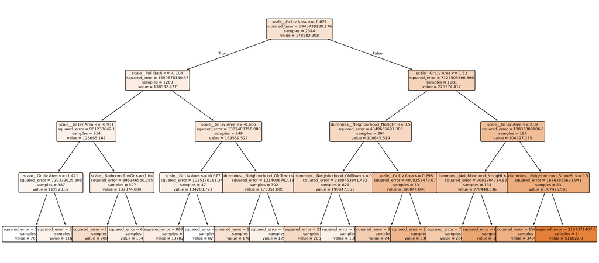

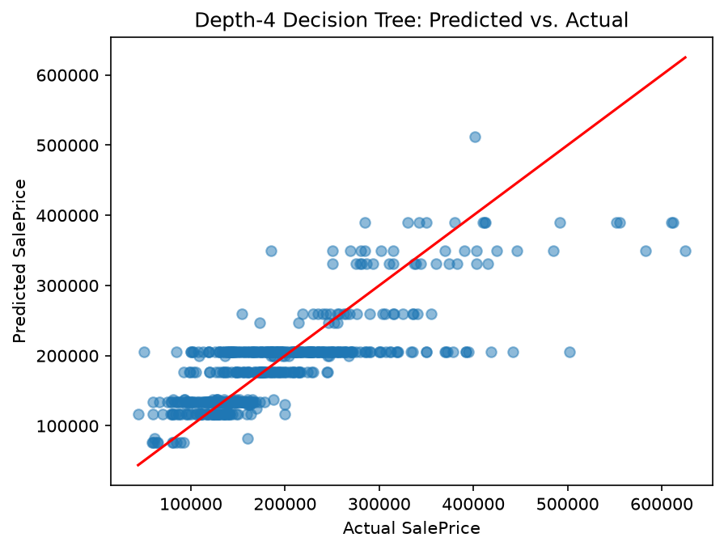

```python
# YOUR CODE HERE. ADD CELLS AS NEEDED
from sklearn.tree import DecisionTreeRegressor, plot_tree

tree_4 = Pipeline([
    ("preprocessing", preprocessor),
    ("tree", DecisionTreeRegressor(max_depth=4, random_state=42))
])

tree_4.fit(X_train, y_train)

tree_pred = tree_4.predict(X_test)

print("Test RMSE:", mean_squared_error(y_test, tree_pred) ** 0.5)
print("Test R-squared:", r2_score(y_test, tree_pred))

feature_names = tree_4.named_steps["preprocessing"].get_feature_names_out()

plt.figure(figsize=(22, 10))

plot_tree(
    tree_4.named_steps["tree"],
    feature_names=feature_names,
    filled=True,
    rounded=True,
    fontsize=8
)

plt.show()

plt.scatter(y_test, tree_pred, alpha=0.5)
plt.xlabel("Actual SalePrice")
plt.ylabel("Predicted SalePrice")
plt.title("Depth-4 Decision Tree: Predicted vs. Actual")
plt.plot([y_test.min(), y_test.max()],
         [y_test.min(), y_test.max()],
         color="red")
plt.show()
```

The tree makes rules using the home features to separate homes into groups. Each final box predicts the average SalePrice for homes that meet the rules in that group. Points closer to the red line are more accurate predictions.

14. Repeat the previous part with different values of `max_depth`. What value of seems to be “best”? How are you deciding?

```python
# YOUR CODE HERE. ADD CELLS AS NEEDED
depths = [2, 3, 4, 5, 6, 8, 10]

tree_results = []

for depth in depths:
    model = Pipeline([
        ("preprocessing", preprocessor),
        ("tree", DecisionTreeRegressor(max_depth=depth, random_state=42))
    ])

    model.fit(X_train, y_train)

    predictions = model.predict(X_test)

    tree_results.append({
        "max_depth": depth,
        "RMSE": mean_squared_error(y_test, predictions) ** 0.5,
        "R-squared": r2_score(y_test, predictions)
    })

tree_results_df = pd.DataFrame(tree_results).sort_values("RMSE")

tree_results_df
```

|  | max_depth | RMSE | R-squared |
| --- | --- | --- | --- |
| 5 | 8 | 43936.633581 | 0.759225 |
| 4 | 6 | 46117.967819 | 0.734724 |
| 6 | 10 | 47162.889975 | 0.722566 |
| 3 | 5 | 50890.653362 | 0.676976 |
| 2 | 4 | 55053.101782 | 0.621974 |
| 1 | 3 | 61394.543324 | 0.529870 |
| 0 | 2 | 64225.037808 | 0.485522 |

I would choose the max depth with the lowest RMSE. A deeper tree can find more detailed patterns, but if it gets too deep it can overfit and not predict new homes as well.